# Untitled-2

Marche aléatoire

par Lucas AGUETAI et Charaf ESSAYAH

Dans le cadre de la **SAE2.02 : Exploration algorithmique d'un problème** Il nous a été demandé de réaliser un projet mathématiques et informatique. Après concertation avec notre enseignant *Mme baroukh* nous avons choisis de réaliser le projet Marche aléatoire.

Voici la description qui a été donnée :

- **Niveau de difficulté :** ☆☆
- **Description :** Partant de 0 un point se déplace de manière équiprobable en haut, en bas, à gauche ou a droite. Est-ce que le point reviendra à l'origine ?
- **Animation :** Le mouvement du point dans le plan jusqu'à ce qu'il revienne en 0 ?

Nous avons travailler environ 30h sur ce projet et avons réparti le travail comme suit :

- **Lucas :** Codage en python et animations
- **Charaf :** Rédaction du notebook et rédaction de l'histoire de l'algorithme

**Histoire de cette algorithme:**

La marche aléatoire est un modèle mathématique qui est une succession de pas aléatoire équiprobable. Cette méthode de marche aléatoire est beaucoup utilisée en mathématiques et en informatique sur des réseaux réguliers ou des graphes complexes. elle est notamment utilisée par le géant Google pour identifier parcourir les pages du réseau internet.

La marche aléatoire fait techniquement partie du domaine des probabilités. en effet elle fait partie d'un processus aléatoire du type chaine de Markov. Elle est décomposée en unités appelées ici "par dont la longueur est fixe et a chaque pas on a un éventail de 4 possibilités pour la direction (haut, bas, gauche, droite) qui est fixe elle aussi il y aura toujours 4 choix de pas par "pas".

La marche aléatoire aussi appelé marche au hasard ou encore random walk en anglais a ete introduite par le biostatisticien Karl Pearson en 1905 pour prendre conscience des migrations d'une population de moustiques.  
Dans notre problème ici, nous partons d'un point X de coordonne [0,0] et on ce deplace de manière aléatoire équiprobable et on doit trouver la probabilité de revenir au point [0,0].

Bibliothèques

Voici les bibliothèques dont nous aurons besoin pour l'exécution des programmes proposés:

```python
from random import *
import matplotlib.pyplot as plt
import numpy as np
from turtle import *
```

Point du Plan

Nous allons devoir placer des points pour la marche aléatoire qui vont être fixe. Avant de se faire nous allons modéliser la notion de point ainsi que de droite.  
Un point est la donnée de deux informations : l'abscisse et l'ordonnée. Informatiquement nous choisissons de modéliser un point par une liste à deux cases : la première case (indice 0) pour l'abscisse et la seconde (indice 1) pour l'ordonnée.

```python
X=[0, 0]

print("Abscisse de", X, ":", X[0])
print("Ordonnée de", X, ":", X[1])
```

```
Abscisse de [0, 0] : 0
Ordonnée de [0, 0] : 0
```

Marche aleatoire

Pour commencer, nous allons commencer à coder le programme qui choisit équiprobablement entre haut, bas, gauche ou droit. On commence par choisir aléatoirement entre la droite X et Y. Enfin on choisit aléatoirement entre 1 et -1 pour savoir si on avance ou on recule sur la droite X ou Y choisit précédemment.

```python
def pointAléatoire() :
    #choisi aléatoirement entre la droite X ou Y
    XorY = randint(1, 2)

    #vérifie quelle est la droite qui va être modifié
    if XorY == 1 :
        print('droite x')

        #choisi aléatoirement entre gauche et droite
        x = randrange(-1, 3, 2)
        if x == 1 :
            print('va à gauche')
        else :
            print('va à droite')
    else :
        print('droite y')

        #choisi aléatoirement entre haut et bas
        y = randrange(-1, 3, 2)
        if y == 1 :
            print('va en haut')
        else :
            print('va en bas')
```

```python
#Test

for i in range(10) :
    pointAléatoire()
```

```
droite y
va en bas
droite y
va en bas
droite x
va à droite
droite x
va à droite
droite x
va à droite
droite y
va en haut
droite x
va à droite
droite x
va à gauche
droite x
va à gauche
droite y
va en bas
```

```python
x=0
y=0
compte = 0
while x != 0 or y != 0 or compte == 0 :
    break
```

Si nous changons les `print()`, ça nous donne ça :

```python
# Initialisation des variables
x = 0
y = 0
compte = 0

while x != 0 or y != 0 or compte == 0 :
        gd = randint(1, 2)
        if gd == 1 :
            x += randrange(-1, 3, 2)
        else :
            y += randrange(-1, 3, 2)
        compte += 1
        if compte>=100000:
            break
```

Maintenant, il nous allons rajouter des tableaux pour sauvegarder toutes les positions où est allé le point.

```python
# Initialisation des variables
x = 0
y = 0
tabx = []
taby = []
compte = 0

while x != 0 or y != 0 or compte == 0 :
        gd = randint(1, 2)
        if gd == 1 :
            x += randrange(-1, 3, 2)
            taby.append(y)
            tabx.append(x)
        else :
            y += randrange(-1, 3, 2)
            taby.append(y)
            tabx.append(x)
        compte += 1
        if compte>=100000:
            break
```

Enfin, il nous manquent plus que de faire une petite phrase pour savoir si le point est revenu ou non, et avec le nombre de pas qu'il a fait.

```python
def Marche_aléatoire() :
    x = 0
    y = 0
    tabx = []
    taby = []
    compte = 0

    while x != 0 or y != 0 or compte == 0 :
            gd = randint(1, 2)
            if gd == 1 :
                x += randrange(-1, 3, 2)
                tabx.append(x)
                taby.append(y)
            else :
                y += randrange(-1, 3, 2)
                taby.append(y)
                tabx.append(x)
            compte += 1
            if compte>=100000:
                break

    if compte>=100000:
        print(f"Le programme à fait {compte} pas, et il n'est pas revenu au départ !")
        compte = -1
    else :
        print(f"Le programme à fait {compte} pas !")

    return[compte, x, y, tabx, taby]
```

```python
#Test

Marche_aléatoire()
```

```
Le programme à fait 4 pas !
```

```
[4, 0, 0, [-1, -1, 0, 0], [0, 1, 1, 0]]
```

Pour mieux appréhender le résultat, nous pouvons faire un petit tableau qui retrace tout ce que le programme a fait !

```python
def Marche_aléatoire_graphique() :
    lance = tirage()
    x = lance[3]
    y = lance[4]

    fig, ax = plt.subplots()
    ax.step(x, y)
    plt.show()
```

[output not shown]

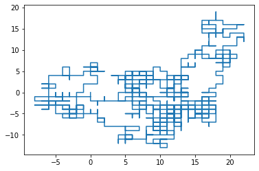

```python
#test

Marche_aléatoire_graphique()
```

Voici aussi un programme qui fait l'animation de la marche aléatoire :

```python
def Marche_aléatoire_animation() :
    x = 0
    y = 0
    compte = 0
    s = Turtle()
    s.begin_fill()

    while x != 0 or y != 0 or compte == 0 :
            gd = randint(1, 2)
            if gd == 1 :
                last_x = x
                x += randrange(-1, 3, 2)
                if x<last_x :
                    s.forward(10)
                else :
                    s.left(180)
                    s.forward(10)
                    s.left(180)
            else :
                last_y = y
                y += randrange(-1, 3, 2)
                if y<last_y :
                    s.right(90)
                    s.forward(10)
                    s.left(90)
                else :
                    s.left(90)
                    s.forward(10)
                    s.right(90)

            compte += 1
            print(compte)
            print('x : ', x, ', y : ', y)
            if compte>=100000:
                break

    if compte>=100000:
        print("Il y a eu ", compte, " tirage, et il n'est pas revenu au départ !")
    else :
        print("Il y a eu ", compte, " tirage !")

    return [x, y]
```

Probabilité

Le but du sujet est de savoir si le point pourra revenir à son point de départ, peut importe l'endroit où il est !

**Explication de la formule probabilité:**

Le point a autant chance d'aller en haut en bas à gauche ou à droite, ce qui nous donne 1 chance sur 4. Imaginons que le point va à droite, la chance pour reviennent au point de départ (à gauche) est de 1 chance sur 4 donc ce qui nous donne $\dfrac{1}{4}*\dfrac{1}{4}$. À partir de ça, on peut simplifier cette probabilité pour que cela nous donne:

$\dfrac{1}{4}^{nombre\ de\ pas}$

Maintenant, faisons un test pour savoir s'il peut revenir :

```python
def proba(nb_pas) :
    return pow(1/4,nb_pas)
```

Pour revenir à l'exemple du dessus, s'il fait seulement 2 déplacements, ça nous donne

```python
print(f'{proba(2)}% de chance de revenir !')
```

```
0.0625% de chance de revenir !
```

```python
for i in range(5):
    print(f'{proba(randrange(1, 500, 2))}')
    print('-----------------------')
```

```
2.1497203544214684e-137
-----------------------
1.2924697071141057e-26
-----------------------
9.273015376718553e-69
-----------------------
1.4210854715202004e-14
-----------------------
0.015625
-----------------------
```

Comme on peut le voir, il y a toujours une probabilité de retour, peu importe le nombre de déplacements !

Conclusion

Pour conclure, notre démonstration montre que le point part des coordonne [0,0], et que, comme le montre notre formule de probabilité, on voit que peut importe le point de départ, il y a une chance que le point revienne au coordonne d'origine !